# Apresentacao_Mecanica_Estatistica slides

**THEORY AND SIMULATION OF THE ISING MODEL**

*Kaue Hermann Abbehausen*

### Duas Categorias da Mecânica Estatística

| **1. Partículas não interagentes:** . Calor Espécifico; . Reações Químicas; . Condensados de Bose-Einstein | **2. Partículas interagentes:** . Transição de Fase; . Ferromagnetismo; . Coexistência de Fase |
| --- | --- |

Energia e consequência

1. Na primeira categoria a energia depende dos níveis de energia da partícula
2. Na segunda categoria **não podemos dizer o mesmo**

## Modelo mental simples

Uma grade onde pontos desta grade são sítios, e as interações são dadas pelos vizinhos mais próximos.

- **Ferromagnetismo:** Os sítios são ocupados por átomo com momento magnético $\mu = g.\mu_\beta.\sqrt{(J(J+1))}$. g é fator de Lande e $\mu_\beta = \frac{e}{2mc}$ o magneton de Bohr.

Cada microestado deste sistema tem uma energia associada as interações de pares e associada a um campo magnético, se existir. $\\ E_{ij} = K_{ij} \pm J_{ij}$ e $$ K_{ij} =\iint \phi_i(r_1)\phi_i^*(r_1)\hat u_{ij} \phi_j(r_2)\phi_j^*(r_2)dr_1 dr_2 \\ J_{ij} =\iint \phi_j^*(r_2)\phi_i^*(r_1)\hat u_{ij} \phi_i(r_1)\phi_j(r_2)dr_1 dr_2 $$

Onde $\phi_i(r_1)$ é a função de onda partícula $i$ na posição $r_1$

## Energia e Hamiltoniana

$$E_s - E_t = 2J$$

$$\hat H = -2 \sum\limits_{i>j}{J_{ij}s_i.s_j}$$$$\hat H = -2 \sum\limits_{i>j}{J_{ij}s_i.s_j} - \mu.B\sum\limits_{i}{\hat \sigma_i}$$

[figure not shown]

## Entropia do sistema

**1. Todos spins iguais: Up ou Down**

$$ S = k_b \ln{\Omega} =k_b \ln{2} $$

**2. Apenas um spin diferente:** $$ S = k_b \ln{\Omega} = k_b \ln{\frac{N!}{(N-1)!}} = k_b \ln{25} $$

**3. Estado de maior entropia:** $$ S = k_b \ln{\Omega} = k_b \ln{\frac{N!}{(N-N/2)!}} $$

### A magnetização fica:

- Caso 1 e 2: Up ou Down: **Há Magnetização espontânea**
- Caso 3: Maior entropia: **Não há magnetização**

### Papel da temperatura:

Existe uma temperatura crítica para a transição de fase.

- Para $T < T_c$ temos $M > 0$
- Para $T > T_c$ temos $M = 0$

**Temos a Quebra espontânea da simetria em $T_c$**

### Valor médio de uma observável A :

$$ \langle A\rangle =\frac{\int A(p,q)e^{-\beta E(q,p)} d^{DN}q d^{DN}p}{\int e^{-\beta E(q,p)} d^{DN}q d^{DN}p} $$

### Método de Monte Carlo

$$ \langle A\rangle =\frac{1}{M} \sum\limits_{i}^{M} A(q_i) $$

## Monte Carlo e Algoritmo de Metropolis

**No Monte Carlo**: Pesa com o fator de peso de Boltzman a amostra randomicamente criada.

**Algoritmo de Metropolis(Importance Sampling)**: Organiza as amostras (microestado) de acordo com o fator de peso.

## Algoritmo de Metropolis

$$ \overline{P}(q) =\frac{e^{-\beta E(q)}}{\sum\limits_{q'} e^{-\beta E(q')} } $$$$ \frac{P(q')}{P(q)} = e^{-\beta (E(q') - E(q))} $$

Durante o algoritmo vamos realizar caminhadas aleatórias na grade e usar esta equação para pesar se o movimento acontece ou não.

Passos e Detalhes do Algoritmo

1. Mude o microestado para outro aleatoriamente. Ocorre mudança direta na energia total.
2. Calcula a diferença de energia $\Delta E$.
- Se $E(q') \le E(q)$ então $P(q') \ge P(q)$, logo **a mudaça é aceita**.
- Caso Se $E(q') \ge E(q)$ então $P(q') \le P(q)$, então escolha aleatóriamente um valor entre 0 e 1,e se $ rand() \le e^{-\beta \Delta E}$ **a mudança é aceita**.
1. Repita os passos 1 a 2 para todos os spins, um de cada vez. Este passo determina uma varredura de monte carlo.
2. Repita os passos 1 a 3 até que o sistema esteja em equilíbrio(eqstp).
3. Repita os passos 1 a 3 para um número de varreduras de Monte Carlo (mcstp).

Passos e Detalhes do Algoritmo

- Antes: $$E(q) = E_o + s_{ij}(s_{i+1,j} + s_{i-1,j} + s_{i,j+1} + s_{i,j-1})$$
- Depois: $$E(q') = E_o - s_{ij}(s_{i+1,j} + s_{i-1,j} + s_{i,j+1} + s_{i,j-1})$$ $E_o$ é a energia de todo o sistemas excluindo estes 5 spins.

Assim temos $$\Delta E = -2 s_{ij}(s_{i+1,j} + s_{i-1,j} + s_{i,j+1} + s_{i,j-1})$$

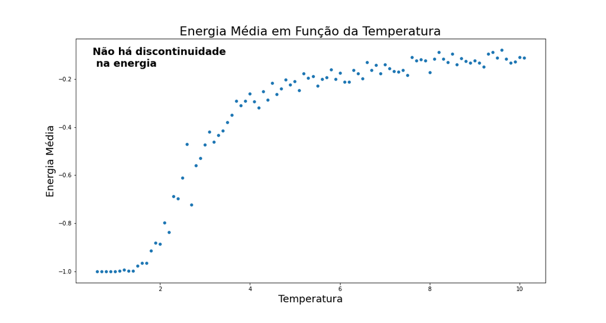

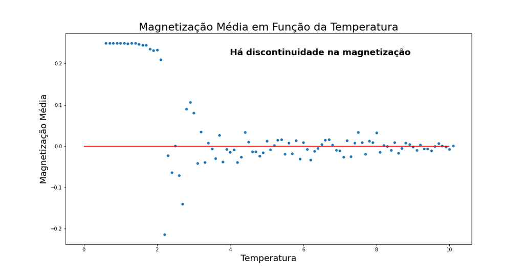

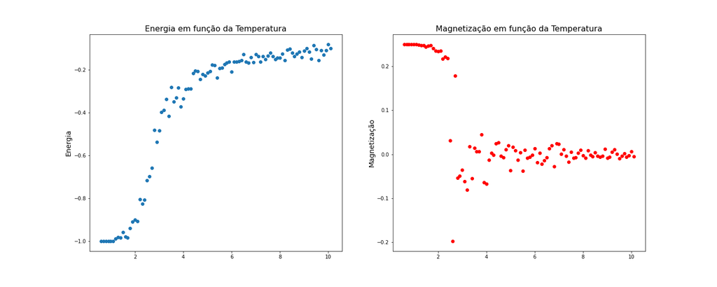

### Para Calcular $C_v$

$$C_v = \frac{\langle E^2\rangle - \langle E\rangle^2}{K_b T^2} $$

### Para Calcular $\chi$

$$\chi = \frac{\langle M^2\rangle - \langle M\rangle^2}{K_b T^2} $$

[figure not shown]

# Referência

Shekaari, Ashkan; Jafari, Mahmoud.Theory and Simulation of the Ising Model.Disponível em: https://arxiv.org/abs/2105.00841v1. Acesso em: 26/08/2022.